# WLE Dataset Prediction

Maksim K

28 02 2017

## Project description

Using devices such as Jawbone Up, Nike FuelBand, and Fitbit it is now possible to collect a large amount of data about personal activity relatively inexpensively. These type of devices are part of the quantified self movement – a group of enthusiasts who take measurements about themselves regularly to improve their health, to find patterns in their behavior, or because they are tech geeks. One thing that people regularly do is quantify how much of a particular activity they do, but they rarely quantify how well they do it.

In this project, my goal will be to use data from accelerometers on the belt, forearm, arm, and dumbell of 6 participants. They were asked to perform barbell lifts correctly and incorrectly in 5 different ways.

The goal of this project is to predict the manner in which they did the exercise. This is the “classe” variable in the next training set:

```r
library(dplyr)
library(caret)
load("~/Desktop/R projects/WLE prediction/session.RData")
trainData <- read.csv("pml-training.csv", header = T, sep =",", stringsAsFactors = FALSE)
str(trainData)
```

```
## 'data.frame':    19622 obs. of  160 variables:
##  $ X                       : int  1 2 3 4 5 6 7 8 9 10 ...
##  $ user_name               : chr  "carlitos" "carlitos" "carlitos" "carlitos" ...
##  $ raw_timestamp_part_1    : int  1323084231 1323084231 1323084231 1323084232 1323084232 1323084232 1323084232 1323084232 1323084232 1323084232 ...
##  $ raw_timestamp_part_2    : int  788290 808298 820366 120339 196328 304277 368296 440390 484323 484434 ...
##  $ cvtd_timestamp          : chr  "05/12/2011 11:23" "05/12/2011 11:23" "05/12/2011 11:23" "05/12/2011 11:23" ...
##  $ new_window              : chr  "no" "no" "no" "no" ...
##  $ num_window              : int  11 11 11 12 12 12 12 12 12 12 ...
##  $ roll_belt               : num  1.41 1.41 1.42 1.48 1.48 1.45 1.42 1.42 1.43 1.45 ...
##  $ pitch_belt              : num  8.07 8.07 8.07 8.05 8.07 8.06 8.09 8.13 8.16 8.17 ...
##  $ yaw_belt                : num  -94.4 -94.4 -94.4 -94.4 -94.4 -94.4 -94.4 -94.4 -94.4 -94.4 ...
##  $ total_accel_belt        : int  3 3 3 3 3 3 3 3 3 3 ...
##  $ kurtosis_roll_belt      : chr  "" "" "" "" ...
##  $ kurtosis_picth_belt     : chr  "" "" "" "" ...
##  $ kurtosis_yaw_belt       : chr  "" "" "" "" ...
```

[output cut: 86 more lines]

Let’s see variables frequency ratio and percent of unique variables in this dataset.

It also required to change the type of a variable “classe” as factor.

```r
trainData$classe <- as.factor(trainData$classe)
nearZeroVar(trainData, saveMetrics = TRUE)
```

```
##                            freqRatio percentUnique zeroVar   nzv
## X                           1.000000  100.00000000   FALSE FALSE
## user_name                   1.100679    0.03057792   FALSE FALSE
## raw_timestamp_part_1        1.000000    4.26562022   FALSE FALSE
## raw_timestamp_part_2        1.000000   85.53154622   FALSE FALSE
## cvtd_timestamp              1.000668    0.10192641   FALSE FALSE
## new_window                 47.330049    0.01019264   FALSE  TRUE
## num_window                  1.000000    4.37264295   FALSE FALSE
## roll_belt                   1.101904    6.77810621   FALSE FALSE
## pitch_belt                  1.036082    9.37722964   FALSE FALSE
## yaw_belt                    1.058480    9.97349913   FALSE FALSE
## total_accel_belt            1.063160    0.14779329   FALSE FALSE
## kurtosis_roll_belt       1921.600000    2.02323922   FALSE  TRUE
## kurtosis_picth_belt       600.500000    1.61553358   FALSE  TRUE
## kurtosis_yaw_belt          47.330049    0.01019264   FALSE  TRUE
## skewness_roll_belt       2135.111111    2.01304658   FALSE  TRUE
## skewness_roll_belt.1      600.500000    1.72255631   FALSE  TRUE
## skewness_yaw_belt          47.330049    0.01019264   FALSE  TRUE
## max_roll_belt               1.000000    0.99378249   FALSE FALSE
## max_picth_belt              1.538462    0.11211905   FALSE FALSE
## max_yaw_belt              640.533333    0.34654979   FALSE  TRUE
## min_roll_belt               1.000000    0.93772296   FALSE FALSE
## min_pitch_belt              2.192308    0.08154113   FALSE FALSE
## min_yaw_belt              640.533333    0.34654979   FALSE  TRUE
## amplitude_roll_belt         1.290323    0.75425543   FALSE FALSE
## amplitude_pitch_belt        3.042254    0.06625217   FALSE FALSE
## amplitude_yaw_belt         50.041667    0.02038528   FALSE  TRUE
## var_total_accel_belt        1.426829    0.33126083   FALSE FALSE
## avg_roll_belt               1.066667    0.97339721   FALSE FALSE
## stddev_roll_belt            1.039216    0.35164611   FALSE FALSE
## var_roll_belt               1.615385    0.48924676   FALSE FALSE
## avg_pitch_belt              1.375000    1.09061258   FALSE FALSE
## stddev_pitch_belt           1.161290    0.21914178   FALSE FALSE
## var_pitch_belt              1.307692    0.32106819   FALSE FALSE
## avg_yaw_belt                1.200000    1.22311691   FALSE FALSE
## stddev_yaw_belt             1.693878    0.29558659   FALSE FALSE
## var_yaw_belt                1.500000    0.73896647   FALSE FALSE
## gyros_belt_x                1.058651    0.71348486   FALSE FALSE
## gyros_belt_y                1.144000    0.35164611   FALSE FALSE
## gyros_belt_z                1.066214    0.86127816   FALSE FALSE
```

[output cut: 106 more lines]

```
## stddev_pitch_forearm       41.500000    1.64611151   FALSE  TRUE
## var_pitch_forearm          83.000000    1.65120783   FALSE  TRUE
## avg_yaw_forearm            83.000000    1.65120783   FALSE  TRUE
## stddev_yaw_forearm         85.000000    1.64101519   FALSE  TRUE
## var_yaw_forearm            85.000000    1.64101519   FALSE  TRUE
## gyros_forearm_x             1.059273    1.51870350   FALSE FALSE
## gyros_forearm_y             1.036554    3.77637346   FALSE FALSE
## gyros_forearm_z             1.122917    1.56457038   FALSE FALSE
## accel_forearm_x             1.126437    4.04647844   FALSE FALSE
## accel_forearm_y             1.059406    5.11160942   FALSE FALSE
## accel_forearm_z             1.006250    2.95586586   FALSE FALSE
## magnet_forearm_x            1.012346    7.76679238   FALSE FALSE
## magnet_forearm_y            1.246914    9.54031189   FALSE FALSE
## magnet_forearm_z            1.000000    8.57710733   FALSE FALSE
## classe                      1.469581    0.02548160   FALSE FALSE
```

We see a lot of columns with null values or with values that are extremely rare.

Let’s continue with the following vars:

```r
training_ <-  select(trainData, one_of(c("roll_belt",
                                     "pitch_belt",
                                     "yaw_belt",
                                     "magnet_belt_x",
                                     "magnet_belt_y",
                                     "magnet_belt_z",
                                     "roll_arm",
                                     "pitch_arm",
                                     "yaw_arm",
                                     "roll_dumbbell",
                                     "pitch_dumbbell",
                                     "yaw_dumbbell",
                                     "roll_forearm",
                                     "pitch_forearm",
                                     "yaw_forearm",
                                     "classe")))

inTrain <- createDataPartition(y=training_$classe,
                               p=0.7, list=FALSE)
training <- training_[inTrain,]
testing <- training_[-inTrain,]
dim(training); dim(testing)
```

```
## [1] 13737    16
```

```
## [1] 5885   16
```

And in order to test our models we’ve sliced training set for trainset and testset. Testset with 20 cases will be used for final validation.

Now let’s see if this variables are correlated with different lifting modes.

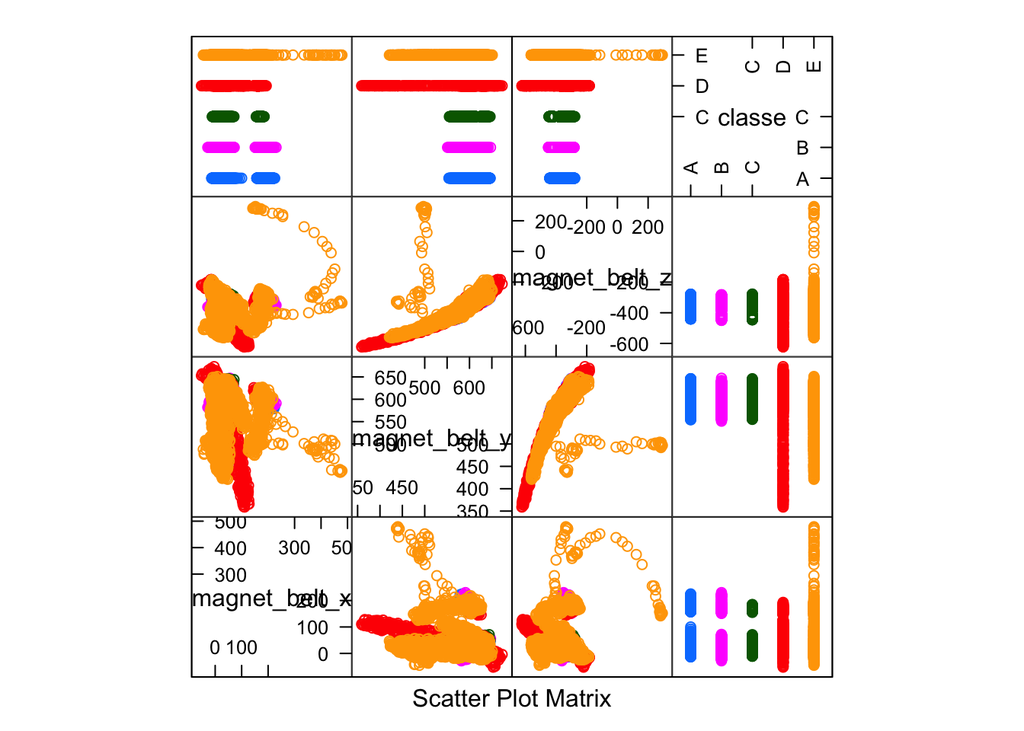

```r
featurePlot(x=training[,c("magnet_belt_x","magnet_belt_y","magnet_belt_z", "classe")],y = training$classe,plot="pairs")
```

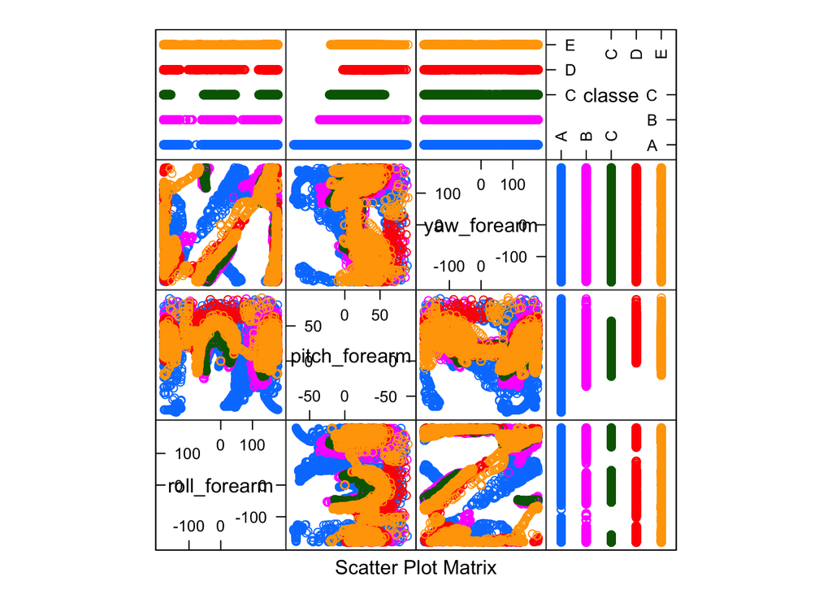

```r
featurePlot(x=training[,c("roll_forearm","pitch_forearm","yaw_forearm","classe")],y = training$classe,plot="pairs")
```

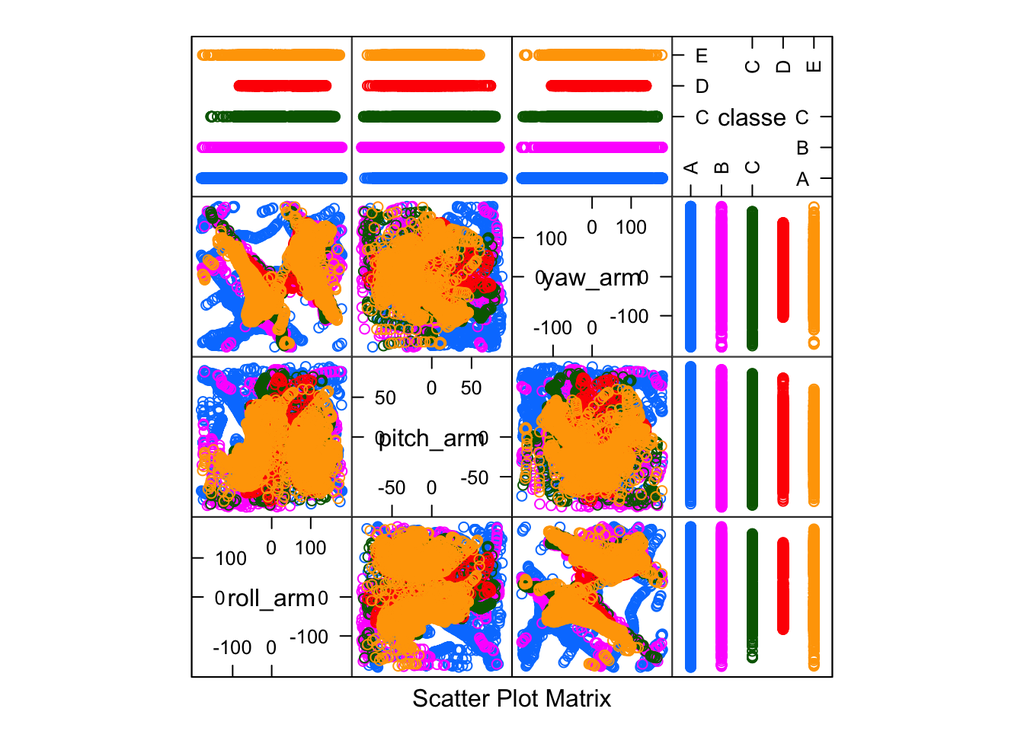

```r
featurePlot(x=training[,c("roll_arm","pitch_arm","yaw_arm","classe")],y = training$classe,plot="pairs")
```

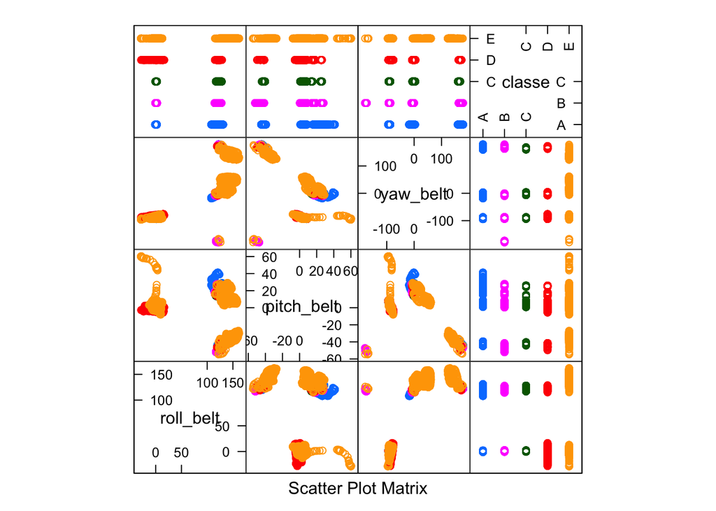

```r
featurePlot(x=training[,c("roll_belt","pitch_belt","yaw_belt","classe")],y = training$classe,plot="pairs")
```

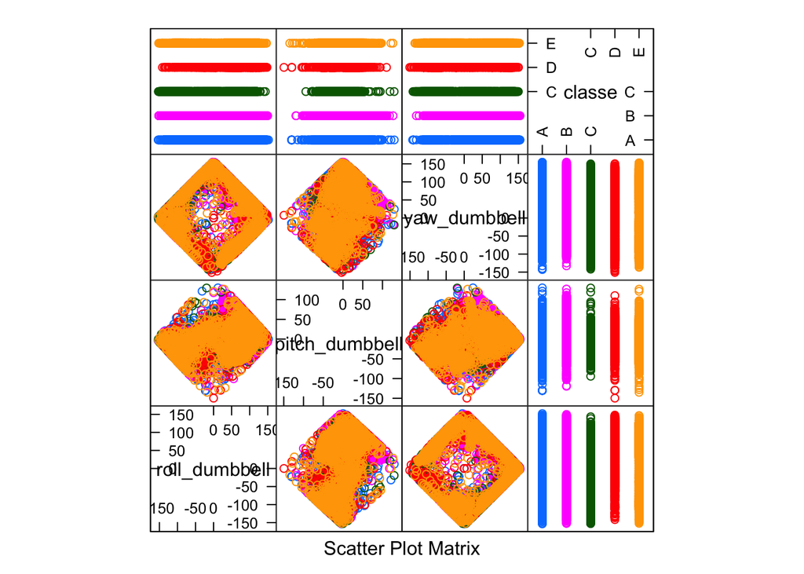

```r
featurePlot(x=training[,c("roll_dumbbell","pitch_dumbbell","yaw_dumbbell","classe")],y = training$classe,plot="pairs")
```

These variables are clearly similar with the description of modes. For example, we can see it on the pitch forearm for mode C. - lifting the dumbbell only halfway

Verifying the quality of the models

```r
confusionMatrix(pred_rf, testing$classe)
```

```
## Confusion Matrix and Statistics
##
##           Reference
## Prediction    A    B    C    D    E
##          A 1673    3    0    0    0
##          B    0 1132    0    2    1
##          C    0    4 1022    1    2
##          D    0    0    3  960    1
##          E    1    0    1    1 1078
##
## Overall Statistics
##
##                Accuracy : 0.9966
##                  95% CI : (0.9948, 0.9979)
##     No Information Rate : 0.2845
##     P-Value [Acc > NIR] : < 2.2e-16
##
##                   Kappa : 0.9957
##  Mcnemar's Test P-Value : NA
##
## Statistics by Class:
##
##                      Class: A Class: B Class: C Class: D Class: E
## Sensitivity            0.9994   0.9939   0.9961   0.9959   0.9963
## Specificity            0.9993   0.9994   0.9986   0.9992   0.9994
## Pos Pred Value         0.9982   0.9974   0.9932   0.9959   0.9972
## Neg Pred Value         0.9998   0.9985   0.9992   0.9992   0.9992
## Prevalence             0.2845   0.1935   0.1743   0.1638   0.1839
## Detection Rate         0.2843   0.1924   0.1737   0.1631   0.1832
## Detection Prevalence   0.2848   0.1929   0.1749   0.1638   0.1837
## Balanced Accuracy      0.9993   0.9966   0.9973   0.9975   0.9978
```

```r
confusionMatrix(pred_lda, testing$classe)
```

```
## Confusion Matrix and Statistics
##
##           Reference
## Prediction    A    B    C    D    E
##          A 1210  311  309  134  216
##          B  161  427  103  227  133
##          C  114  175  488  106  149
##          D  161  153   69  402  131
##          E   28   73   57   95  453
##
## Overall Statistics
##
##                Accuracy : 0.5064
##                  95% CI : (0.4935, 0.5192)
##     No Information Rate : 0.2845
##     P-Value [Acc > NIR] : < 2.2e-16
##
##                   Kappa : 0.3687
##  Mcnemar's Test P-Value : < 2.2e-16
##
## Statistics by Class:
##
##                      Class: A Class: B Class: C Class: D Class: E
## Sensitivity            0.7228  0.37489  0.47563  0.41701  0.41867
## Specificity            0.7697  0.86852  0.88804  0.89555  0.94732
## Pos Pred Value         0.5550  0.40628  0.47287  0.43886  0.64164
## Neg Pred Value         0.8748  0.85271  0.88914  0.88690  0.87855
## Prevalence             0.2845  0.19354  0.17434  0.16381  0.18386
## Detection Rate         0.2056  0.07256  0.08292  0.06831  0.07698
## Detection Prevalence   0.3704  0.17859  0.17536  0.15565  0.11997
## Balanced Accuracy      0.7462  0.62171  0.68184  0.65628  0.68300
```

```r
confusionMatrix(pred_nb, testing$classe)
```

```
## Confusion Matrix and Statistics
##
##           Reference
## Prediction    A    B    C    D    E
##          A 1198  174   73  120   21
##          B  214  655  110   96   72
##          C  130  173  761  216  115
##          D  100  101   62  480   69
##          E   32   36   20   52  805
##
## Overall Statistics
##
##                Accuracy : 0.6625
##                  95% CI : (0.6503, 0.6746)
##     No Information Rate : 0.2845
##     P-Value [Acc > NIR] : < 2.2e-16
##
##                   Kappa : 0.574
##  Mcnemar's Test P-Value : < 2.2e-16
##
## Statistics by Class:
##
##                      Class: A Class: B Class: C Class: D Class: E
## Sensitivity            0.7157   0.5751   0.7417  0.49793   0.7440
## Specificity            0.9079   0.8963   0.8695  0.93253   0.9709
## Pos Pred Value         0.7554   0.5711   0.5455  0.59113   0.8519
## Neg Pred Value         0.8893   0.8978   0.9410  0.90459   0.9439
## Prevalence             0.2845   0.1935   0.1743  0.16381   0.1839
## Detection Rate         0.2036   0.1113   0.1293  0.08156   0.1368
## Detection Prevalence   0.2695   0.1949   0.2370  0.13798   0.1606
## Balanced Accuracy      0.8118   0.7357   0.8056  0.71523   0.8574
```

The best result - RandomForest.

Predicting of set with 20 test cases

```r
test20 <- read.csv("pml-testing.csv", header = T, sep =",", stringsAsFactors = FALSE)
pred_final <- predict(fit_rf, test20)
pred_final
```

```
##  [1] B A B A A E D B A A B C B A E E A B B B
## Levels: A B C D E
```